# Compare the Old CTD vs. New CTD

Adrienne

2023-09-06

This document:

1. Reads in the CTD files
2. Does QAQC if necessary,
3. Finds casts taken at the same reservoir on the same day for comparisons,
4. Plot comparison casts for each date, variable, and reservoir
5. Make a regression plot for each variable
6. Run t-tests for each variable
7. Plot and run Bland Altman Test
8. Plot and run Passin Bablok Test

## Comparison Plots from both CTDs split by date, variable, and reservoir

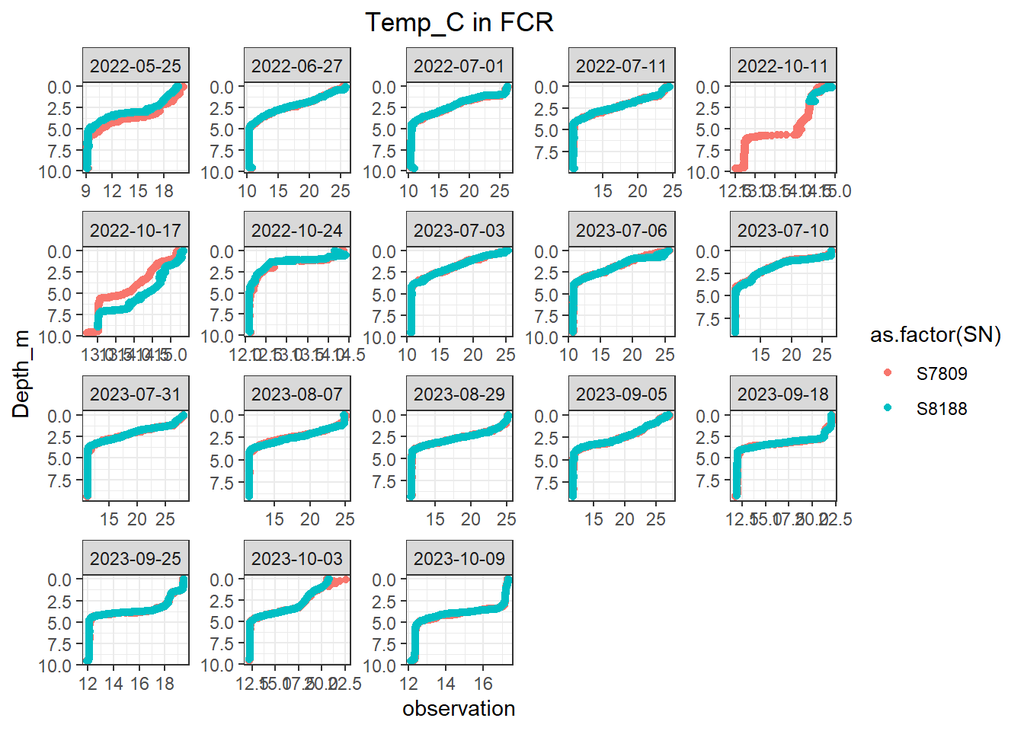

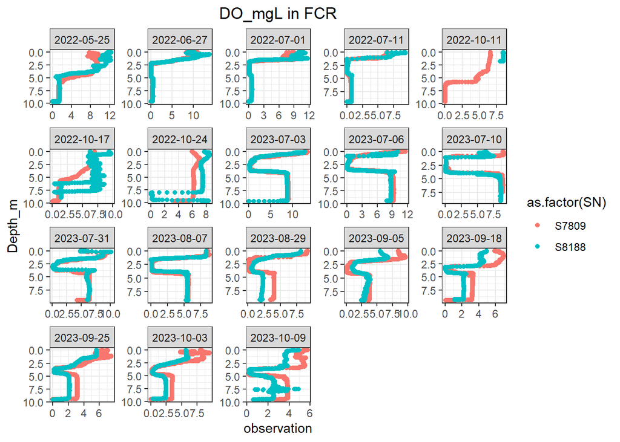

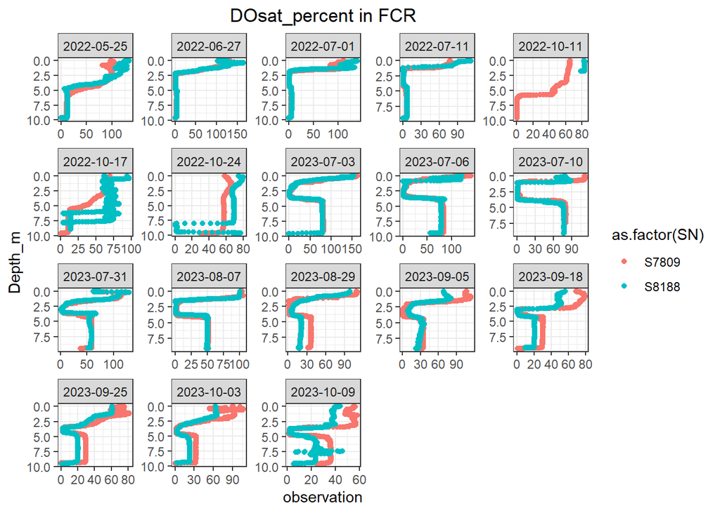

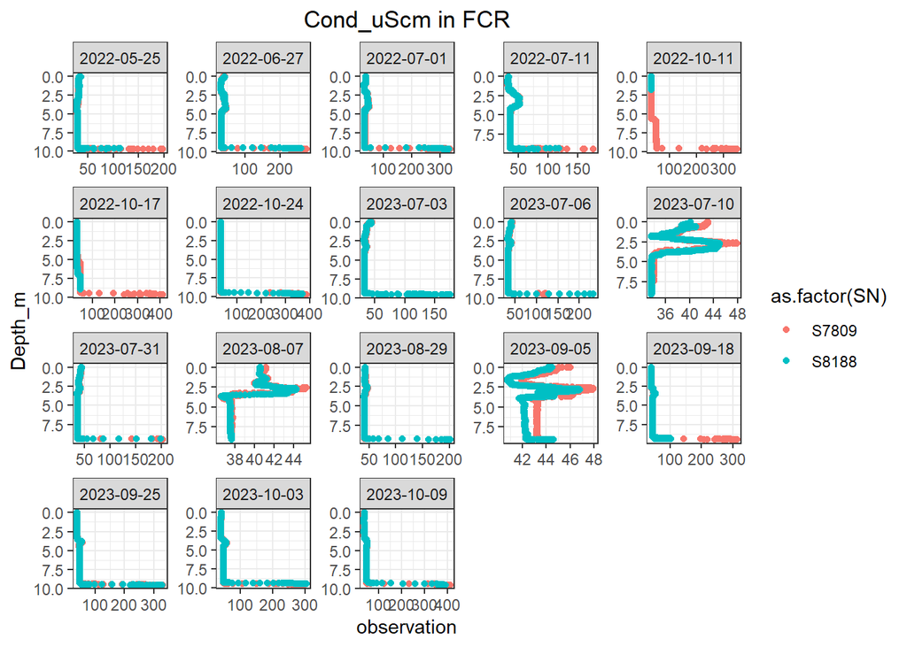

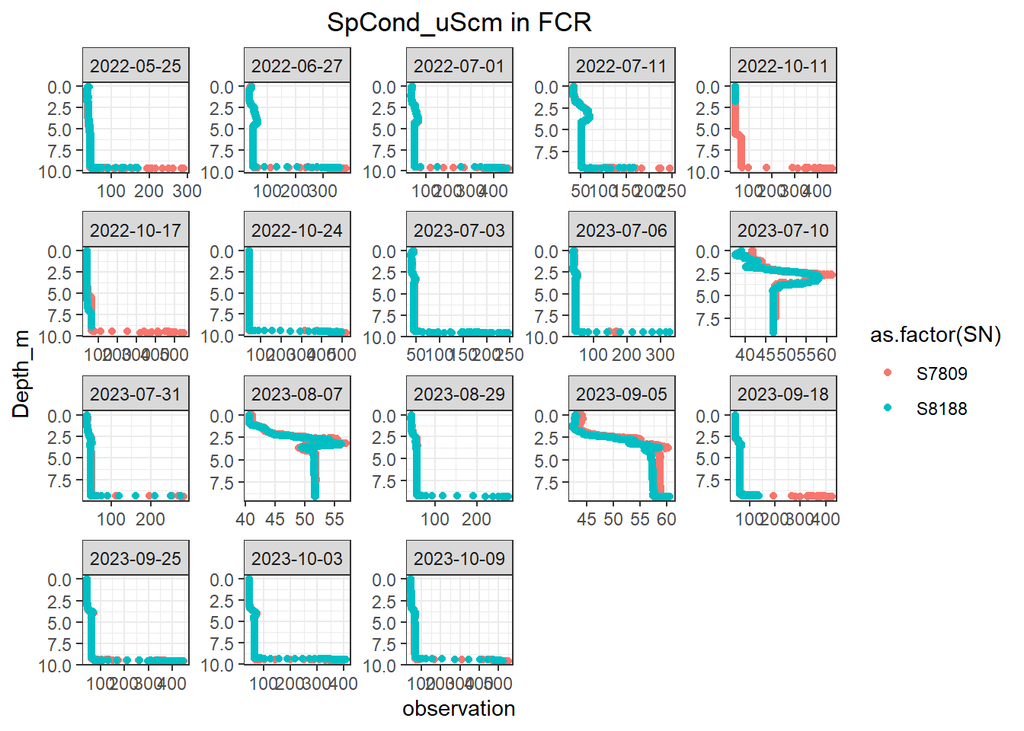

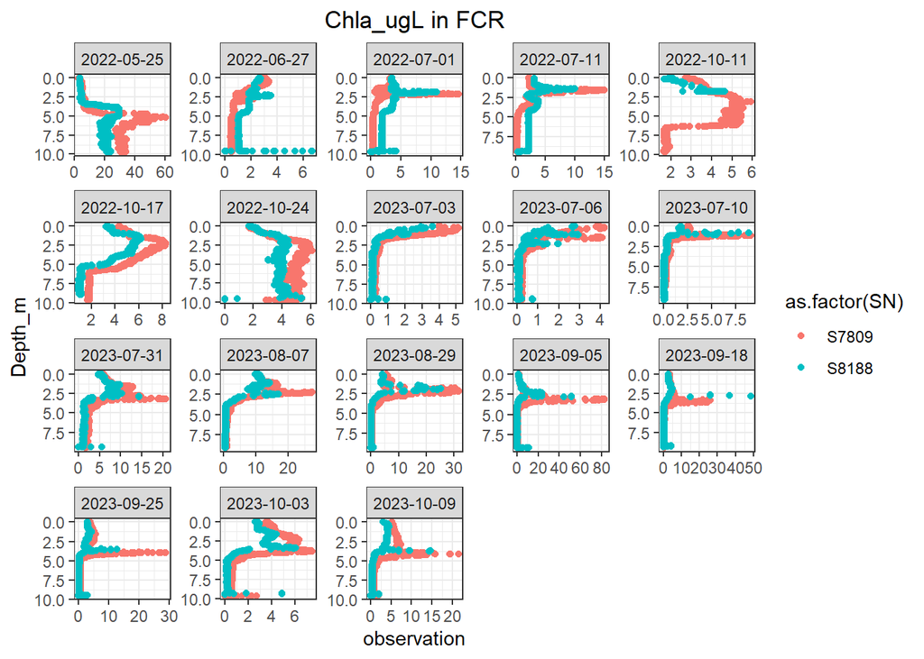

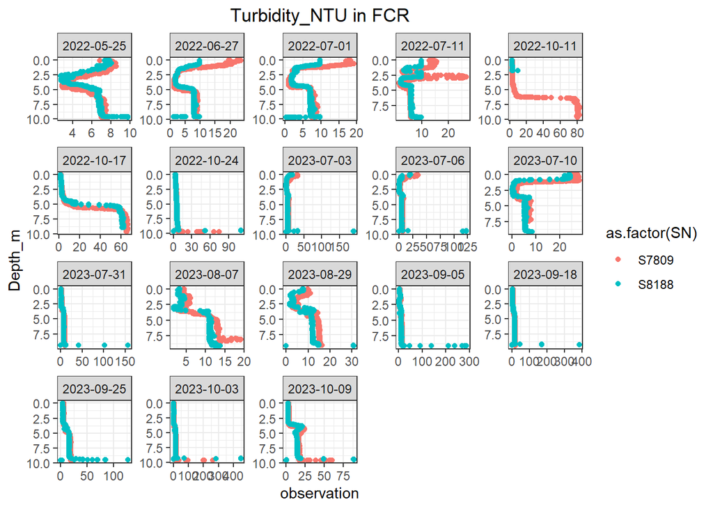

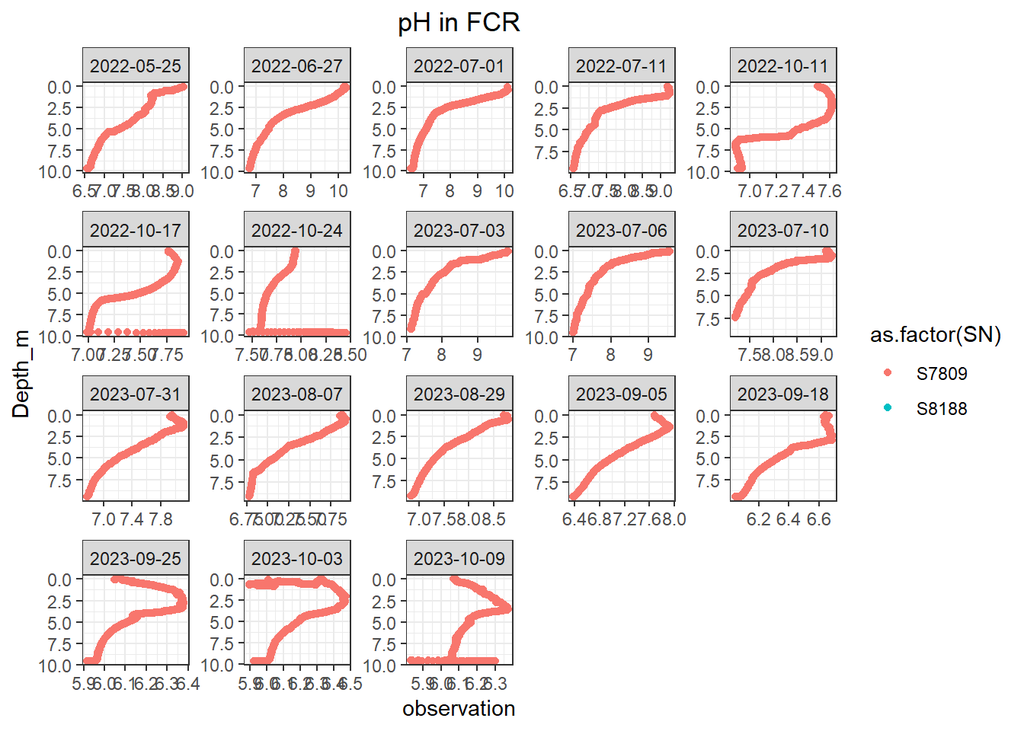

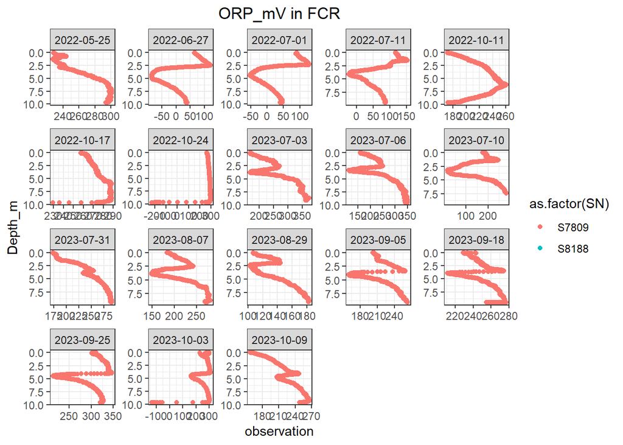

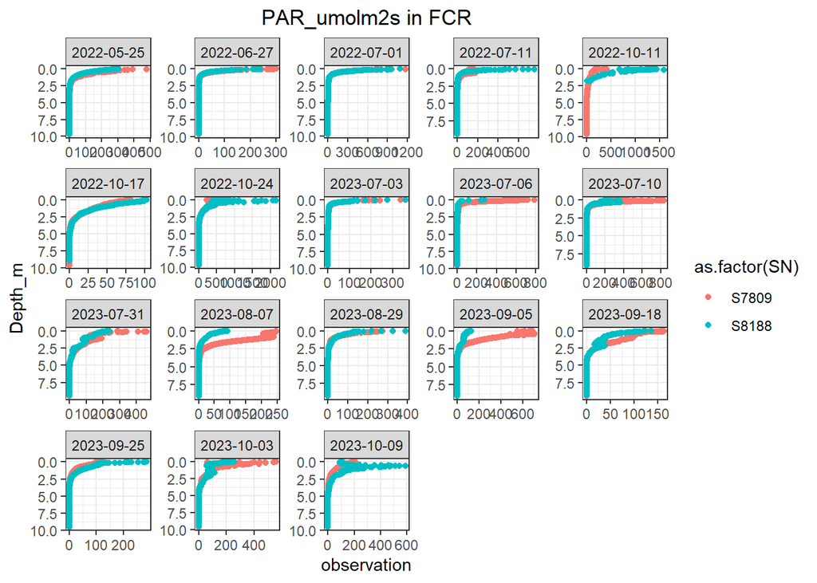

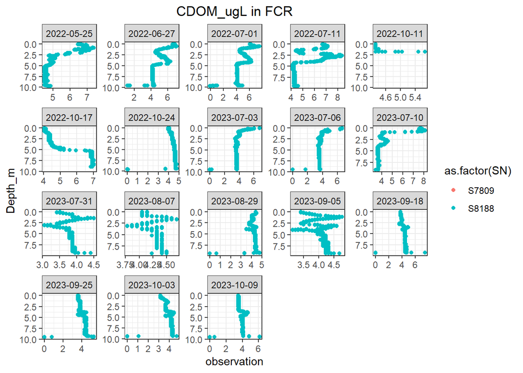

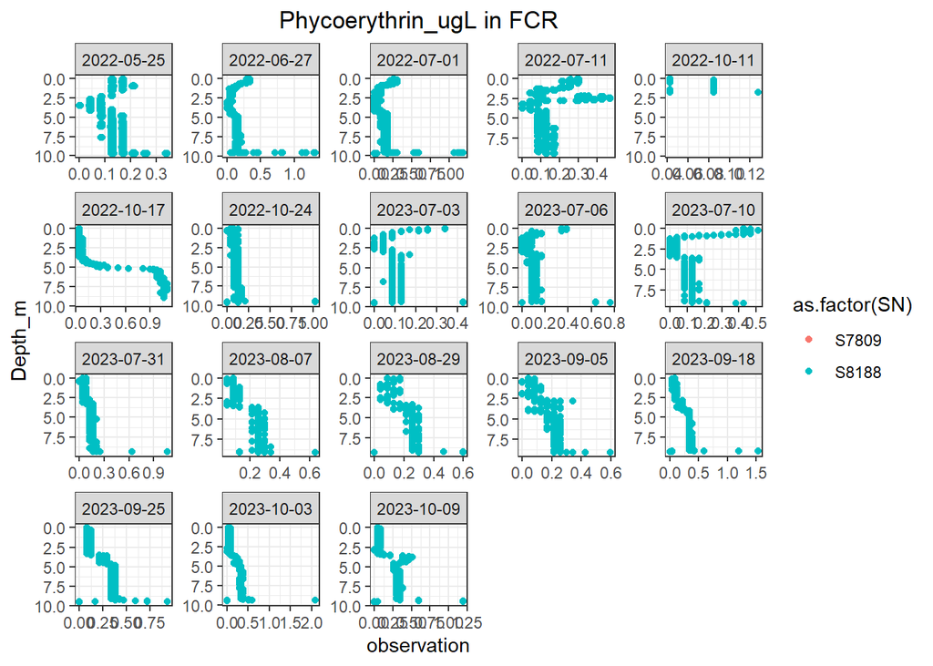

[27 more figures not shown]

### Scatterplots of the old CTD vs. new CTD

[output not shown]

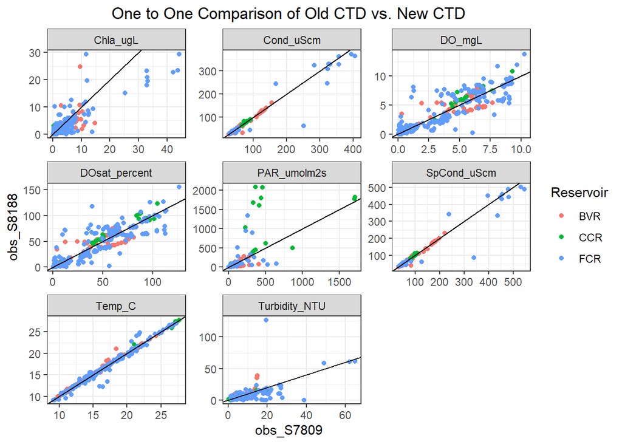

### Notes from Bobbie’s R Script comparing methods in the Analytical Lab

R Script to compare methods in the Analytical Lab Authors: Bobbie Niederlehner Last Edited: 06/07/2022

Steps 1) load the libraries and the data 2) remove lines with missing values for either analysis 3) OPTIONAL: restrict the concentration range being analyzed 4) Paired T-Test- Test differences = 0 with paired T (NOT a preferred way to look at these data but magnitude of difference is interesting) 5) Bland Altman - Visualize differences over concentration (difference over mean concentration) 6) Passing Bablok - Test coincidence across concentrations - regression of new vs reference method. Does it have a slope of 1 and an intercept of 0

BACKGROUND INFO: Some web resources explaining method comparison regressions https://www.r-bloggers.com/deming-and-passing-bablok-regression-in-r/ https://www.r-bloggers.com/2015/09/deming-and-passing-bablok-regression-in-r/ http://labrtorian.com/tag/passing-bablok/ https://www.r-bloggers.com/2016/08/a-shiny-app-for-passing-bablok-and-deming-regression/ https://bahar.shinyapps.io/method_compare/

Notes NOTE: the order of the variables in each analysis can matter FOR paired T-test it doesn’t matter. Just pay attention to sign for difference. Difference is calculated as 1st specified (x) minus 2nd specified (y) FOR Bland Altman it doesn’t matter, Default difference is 1st specified (x) minus 2nd specified (y) FOR Passing Bablok first listed is reference method (x, Method1, or current), second listed is is test method (y, Method2, or new) The intercept is often smean difference, but will have the reverse sign.

### Output from t-tests

```
## [1] "Chla_ugL"
##
##  Paired t-test
##
## data:  a$obs_S7809 and a$obs_S8188
## t = 5.3522, df = 473, p-value = 1.357e-07
## alternative hypothesis: true mean difference is not equal to 0
## 95 percent confidence interval:
##  0.4614384 0.9968195
## sample estimates:
## mean difference
##       0.7291289
##
## [1] "Cond_uScm"
##
##  Paired t-test
##
## data:  a$obs_S7809 and a$obs_S8188
## t = 2.3673, df = 473, p-value = 0.01832
## alternative hypothesis: true mean difference is not equal to 0
## 95 percent confidence interval:
##  0.2021309 2.1769117
## sample estimates:
## mean difference
##        1.189521
##
## [1] "DO_mgL"
##
##  Paired t-test
##
## data:  a$obs_S7809 and a$obs_S8188
## t = -0.76644, df = 473, p-value = 0.4438
## alternative hypothesis: true mean difference is not equal to 0
## 95 percent confidence interval:
##  -0.16245649  0.07128553
## sample estimates:
## mean difference
##     -0.04558548
##
## [1] "DOsat_percent"
```

[output cut: 48 more lines]

```
## mean difference
##    -0.004478697
##
## [1] "Turbidity_NTU"
##
##  Paired t-test
##
## data:  a$obs_S7809 and a$obs_S8188
## t = 2.9141, df = 473, p-value = 0.003736
## alternative hypothesis: true mean difference is not equal to 0
## 95 percent confidence interval:
##  0.2785744 1.4320244
## sample estimates:
## mean difference
##       0.8552994
```

### Plots and outputs from Bland Altman

```
## [1] "Chla_ugL"
## [1] "mean difference" "lower limit"     "upper limit"     "sample size"
## [1]   0.7291289  -5.0841001   6.5423580 474.0000000
```

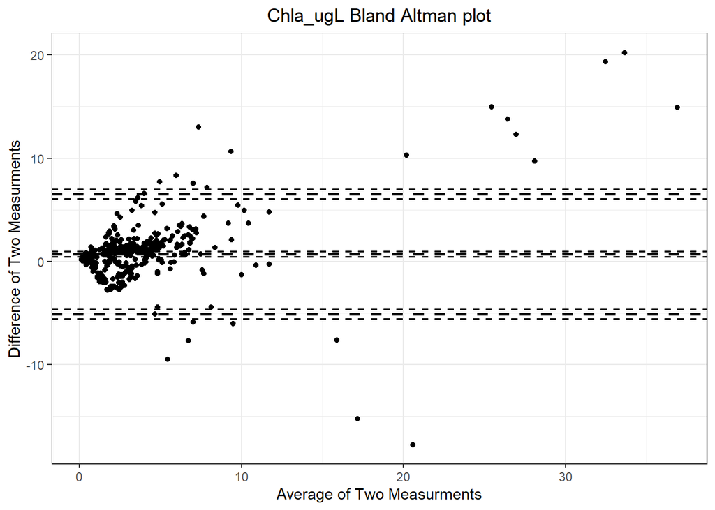

```
## [1] "Cond_uScm"
## [1] "mean difference" "lower limit"     "upper limit"     "sample size"
## [1]   1.189521 -20.252876  22.631919 474.000000
```

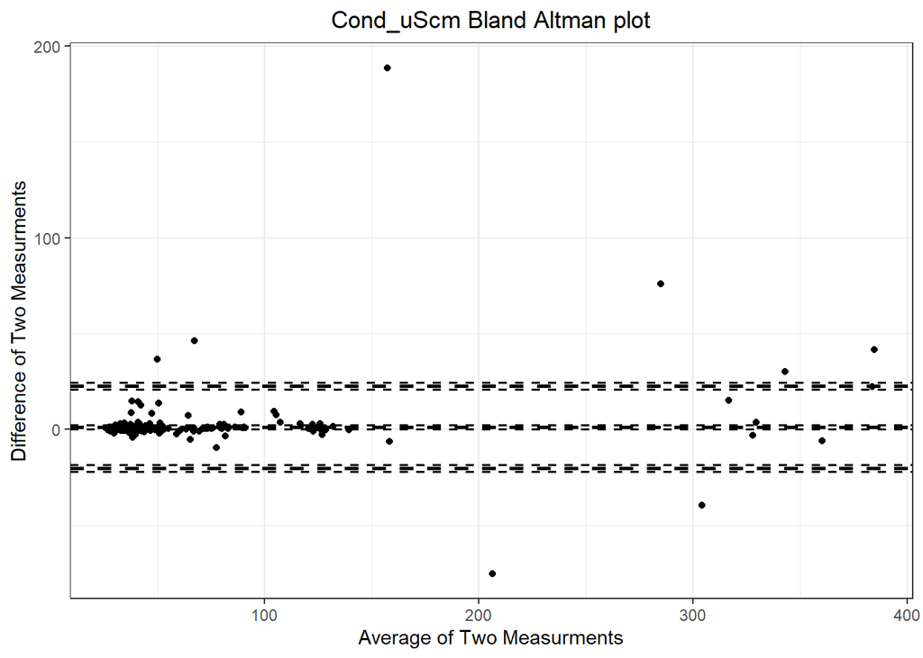

```
## [1] "DO_mgL"
## [1] "mean difference" "lower limit"     "upper limit"     "sample size"
## [1]  -0.04558548  -2.58358336   2.49241240 474.00000000
```

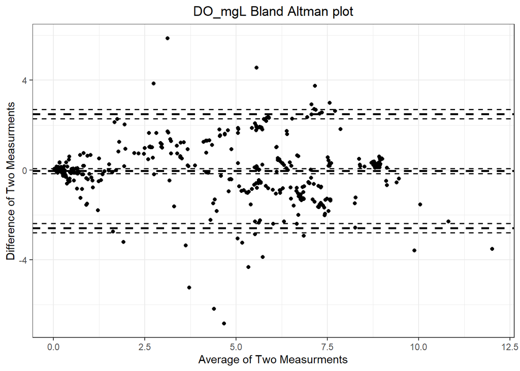

```
## [1] "DOsat_percent"
## [1] "mean difference" "lower limit"     "upper limit"     "sample size"
## [1]  -0.1523317 -26.5242197  26.2195564 474.0000000
```

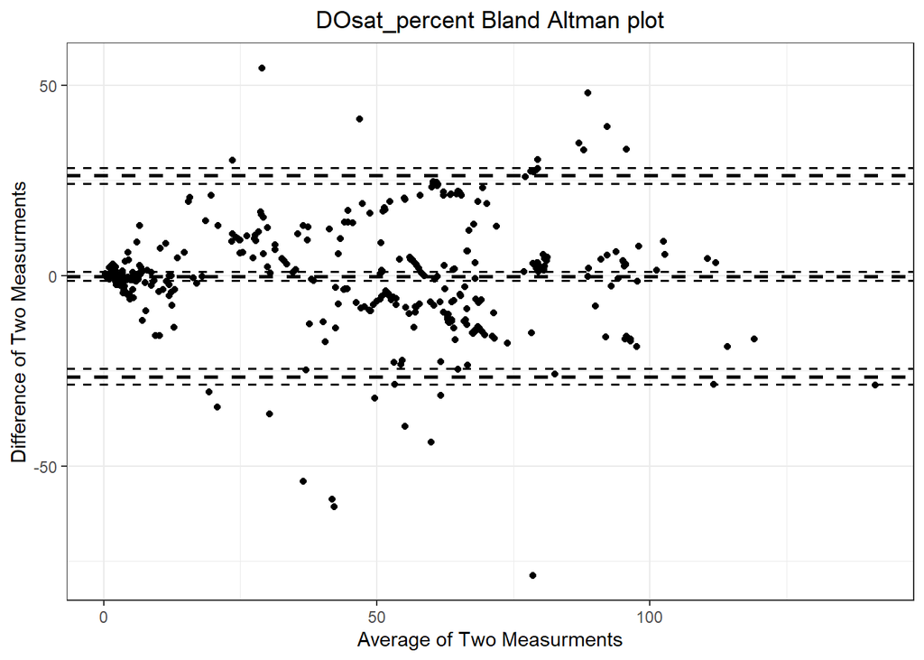

```
## [1] "PAR_umolm2s"
## [1] "mean difference" "lower limit"     "upper limit"     "sample size"
## [1]  -17.55155 -373.19147  338.08837  446.00000
```

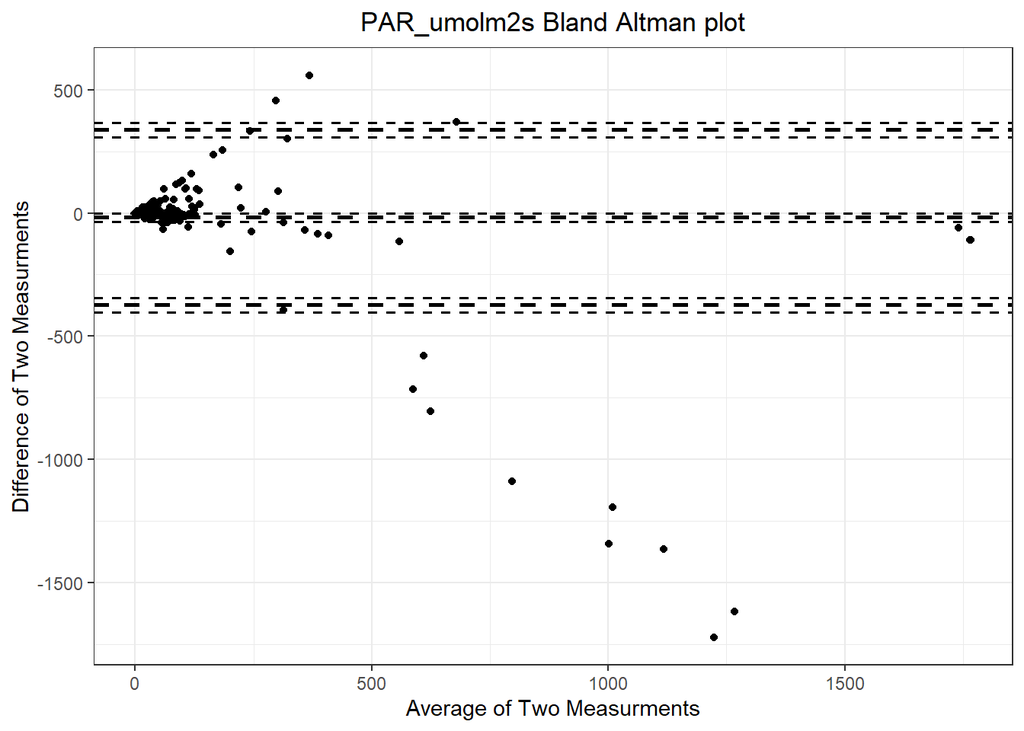

```
## [1] "SpCond_uScm"
## [1] "mean difference" "lower limit"     "upper limit"     "sample size"
## [1]   1.557961 -27.548637  30.664560 474.000000
```

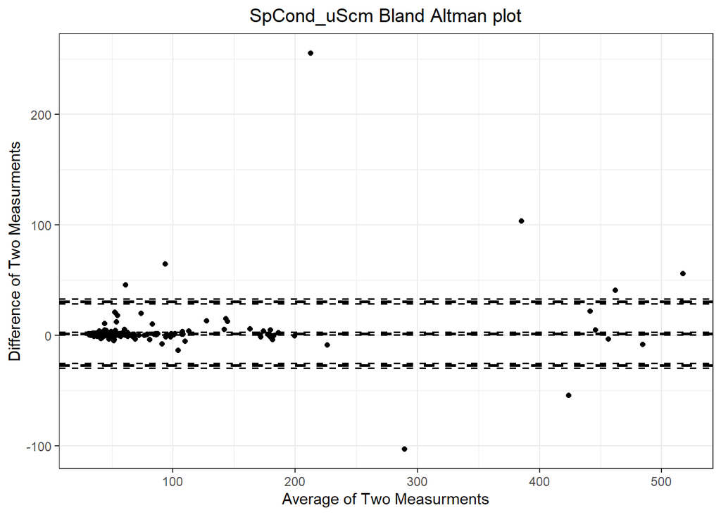

```
## [1] "Temp_C"
## [1] "mean difference" "lower limit"     "upper limit"     "sample size"
## [1]  -0.004478697  -0.970333744   0.961376349 474.000000000
```

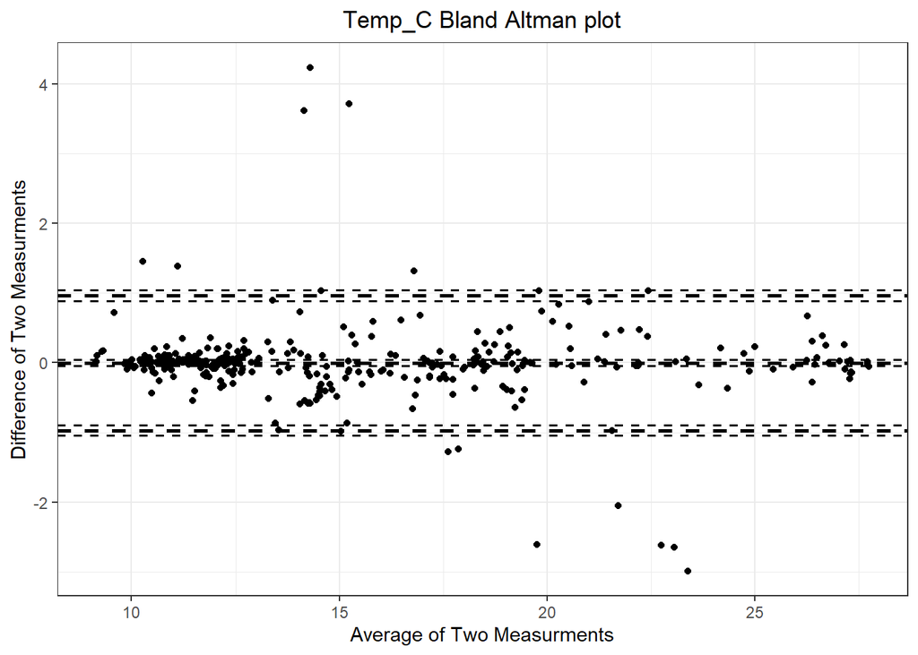

```
## [1] "Turbidity_NTU"
## [1] "mean difference" "lower limit"     "upper limit"     "sample size"
## [1]   0.8552994 -11.6689950  13.3795938 474.0000000
```

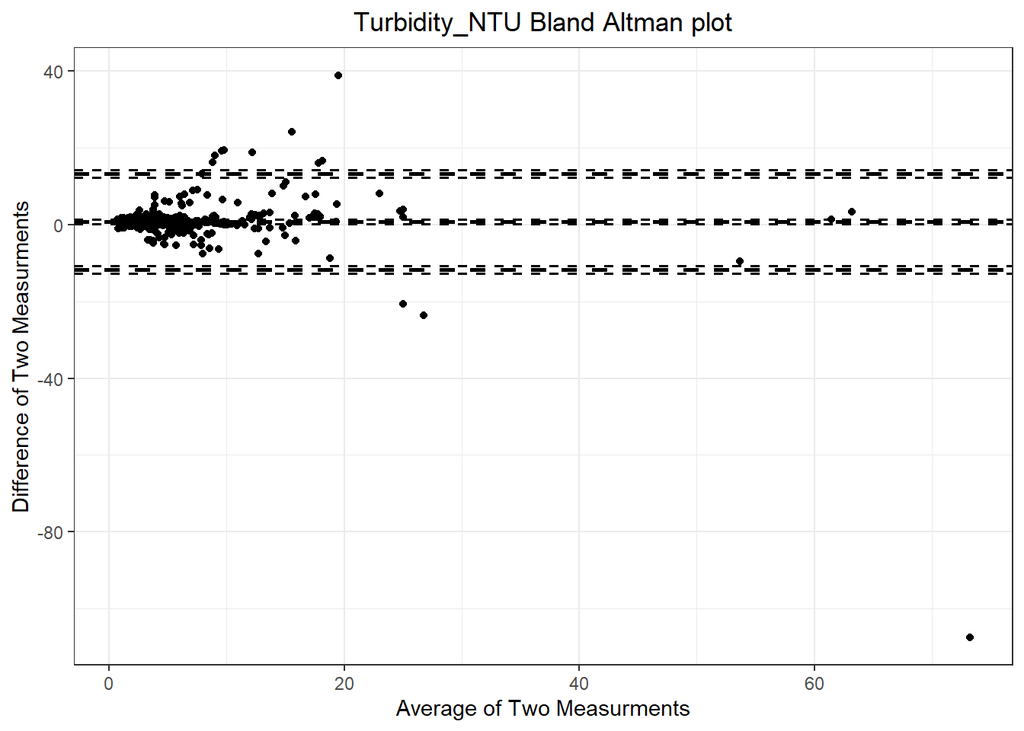

```r
#  Bland Altman Plots (difference over mean)
#      Estimates an agreement interval, within which 95% of the differences fall.
#      BUT criterion for agreement should be decided on apriori and is completely based on judgement - what can you tolerate?

for(b in 1:length(var)){
  a <-round_CTD%>%
    filter(variable==var[b])

  print(var[b])

   ba<-bland.altman.stats(a$obs_S7809,a$obs_S8188, conf.int = 0.95)
#}

print (c("mean difference", "lower limit", "upper limit","sample size"))
print (c(ba$mean.diffs, ba$lower.limit, ba$upper.limit, ba$based.on))

#     IF you prefer GGPLOT2 specify that graph.sys
#         geom_count = TRUE handles overlapping points by making the plot symbol larger
ba2 <- bland.altman.plot(a$obs_S7809,a$obs_S8188, graph.sys = "ggplot2", conf.int=.95, geom_count = F)
print (ba2 +
         xlab("Average of Two Measurments") +
         ylab ("Difference of Two Measurments") +
         ggtitle(paste0(var[b]," Bland Altman plot")) +
         theme_bw()+
          theme(plot.title = element_text(hjust = 0.5)))
}
```

### Passin Bablok Test and Output

Method Comparison Regression using nonparametric Passing Bablok (MORE RESISTANT TO OUTLIERS) The first listed variable definitely ends up on the X axis and documentation says it is the “reference” method The second listed variable ends up on the y axis and documentation says it is the “test” method

```
## [1] "Chla_ugL"
## [1] "Passing Bablok"
##
##
## ------------------------------------------
##
## Reference method: obs_S7809
## Test method:     obs_S8188
## Number of data points: 474
##
## ------------------------------------------
##
## The confidence intervals are calculated with
##  bootstrap  ( quantile ) method.
## Confidence level: 95%
##
##
## ------------------------------------------
##
## PASSING BABLOK REGRESSION FIT:
##
##                   EST SE         LCI        UCI
## Intercept -0.05229128 NA -0.08263953 0.00144695
## Slope      0.71309501 NA  0.68761629 0.75003552
##
##
## ------------------------------------------
##
## BOOTSTRAP SUMMARY
##
##           global.est bootstrap.mean    bias bootstrap.se
## Intercept   -0.05229       -0.04954 0.00275      0.02060
## Slope        0.71310        0.71479 0.00170      0.01584
##
## Bootstrap results generated with environment RNG settings.
## [1] "pearson correlation coefficient"
```

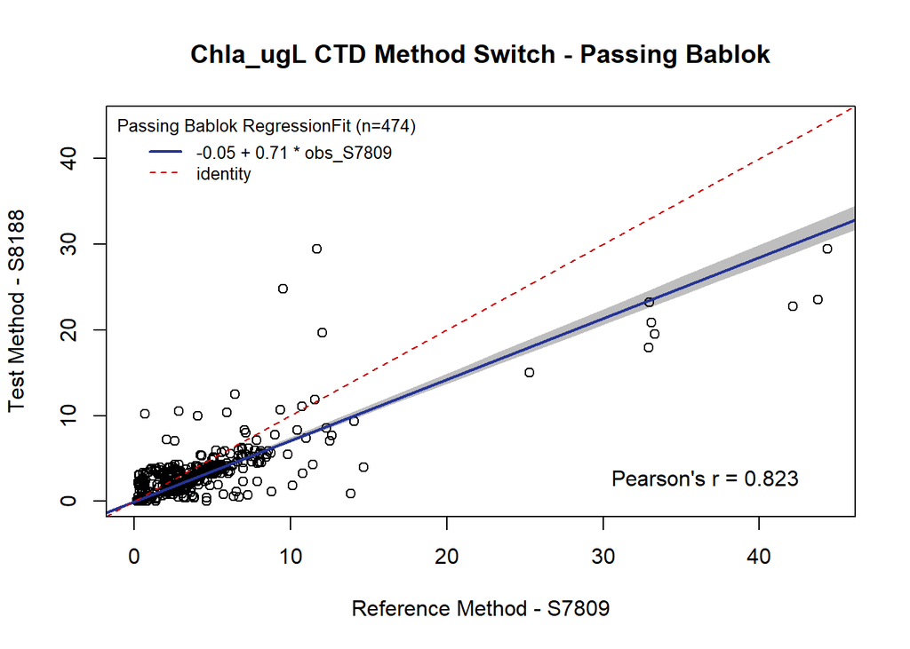

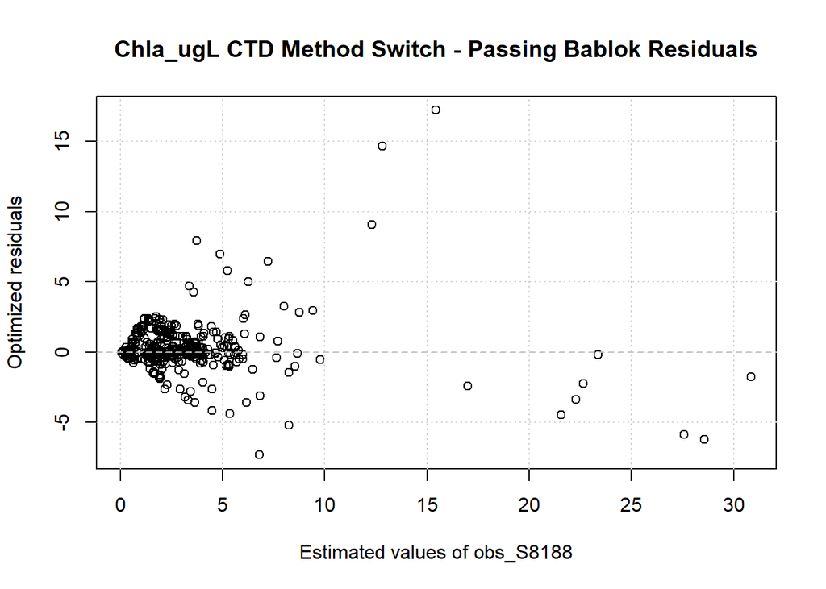

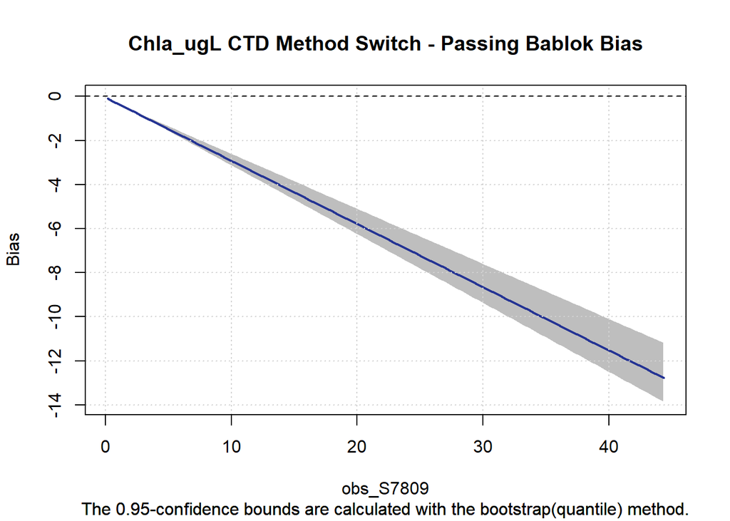

```
## [1] "Cond_uScm"
## [1] "Passing Bablok"
##
##
## ------------------------------------------
##
## Reference method: obs_S7809
## Test method:     obs_S8188
## Number of data points: 474
##
## ------------------------------------------
##
## The confidence intervals are calculated with
##  bootstrap  ( quantile ) method.
## Confidence level: 95%
##
##
## ------------------------------------------
##
## PASSING BABLOK REGRESSION FIT:
##
##                 EST SE       LCI       UCI
## Intercept 0.5489371 NA 0.3357697 0.8191238
## Slope     0.9815700 NA 0.9743841 0.9871454
##
##
## ------------------------------------------
##
## BOOTSTRAP SUMMARY
##
##           global.est bootstrap.mean     bias bootstrap.se
## Intercept    0.54894        0.55865  0.00971      0.11947
## Slope        0.98157        0.98123 -0.00034      0.00322
##
## Bootstrap results generated with environment RNG settings.
## [1] "pearson correlation coefficient"
```

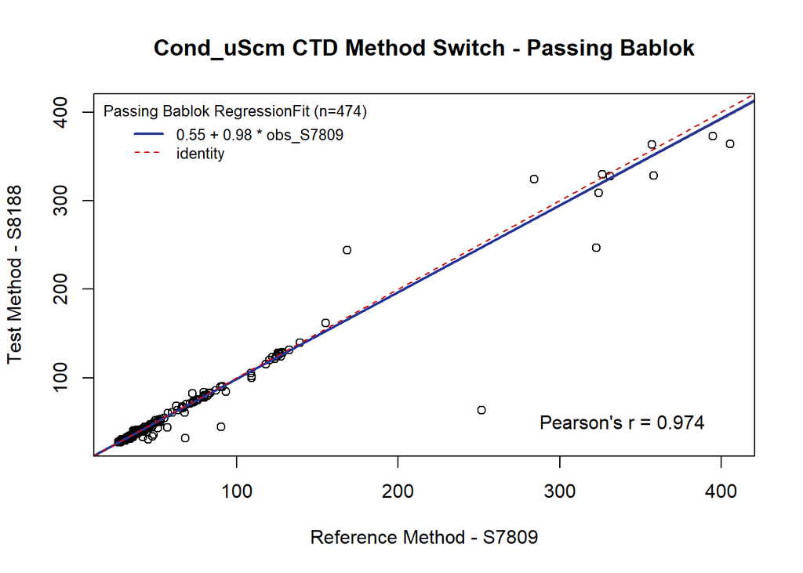

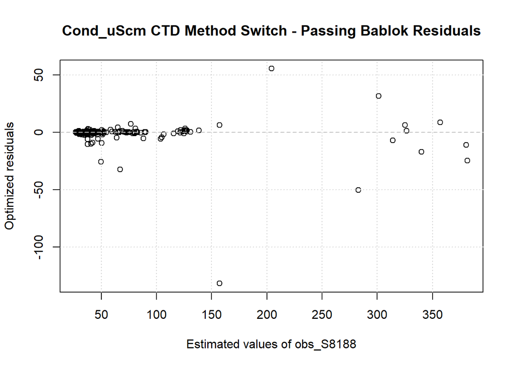

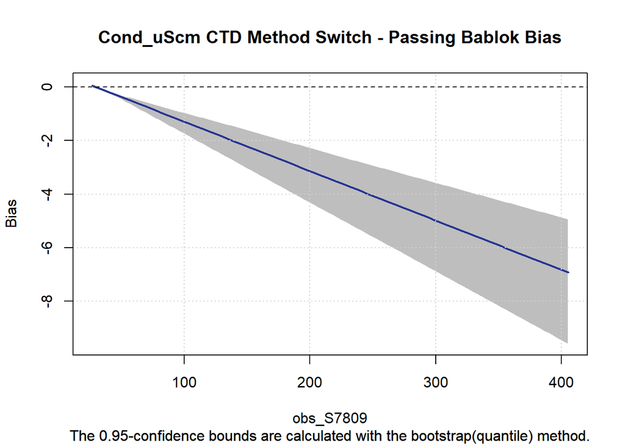

```
## [1] "DO_mgL"
## [1] "Passing Bablok"
##
##
## ------------------------------------------
##
## Reference method: obs_S7809
## Test method:     obs_S8188
## Number of data points: 474
##
## ------------------------------------------
##
## The confidence intervals are calculated with
##  bootstrap  ( quantile ) method.
## Confidence level: 95%
##
##
## ------------------------------------------
##
## PASSING BABLOK REGRESSION FIT:
##
##                  EST SE         LCI        UCI
## Intercept 0.01062113 NA -0.02823863 0.03700834
## Slope     1.02626471 NA  0.98215583 1.07509138
##
##
## ------------------------------------------
##
## BOOTSTRAP SUMMARY
##
##           global.est bootstrap.mean     bias bootstrap.se
## Intercept    0.01062        0.01018 -0.00044      0.01974
## Slope        1.02626        1.02657  0.00031      0.02494
##
## Bootstrap results generated with environment RNG settings.
## [1] "pearson correlation coefficient"
```

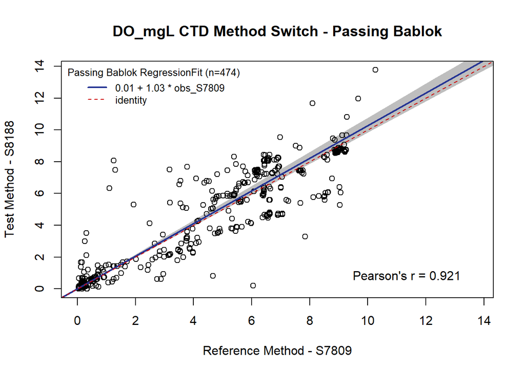

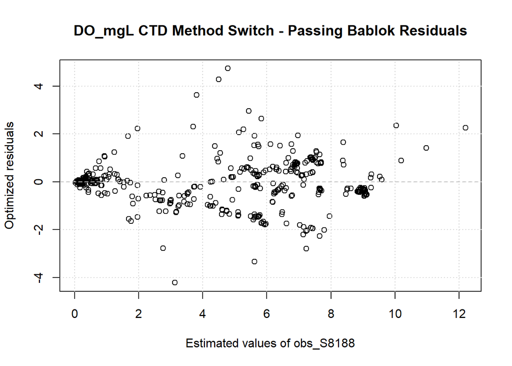